# HW5 – Ying Zheng

Problem 1

[figure not shown]

```r
holdfit = VAR(data, lag.max=20)
holdfit$p
```

```
AIC(n)
    10
```

```r
serial.test(holdfit)
```

```
    Portmanteau Test (asymptotic)

data:  Residuals of VAR object holdfit
Chi-squared = 76.129, df = 54, p-value = 0.02528
```

The p-value is 0.02528, which is smaller than 0.05, shows evidence of serial correlation in residuals.

Problem 2 (a)

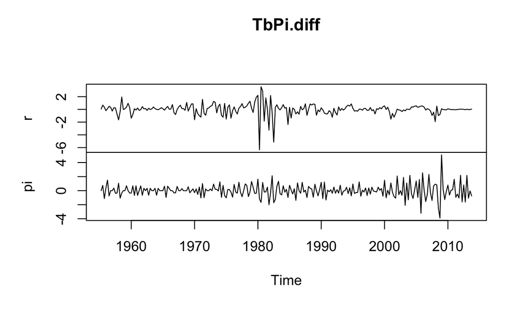

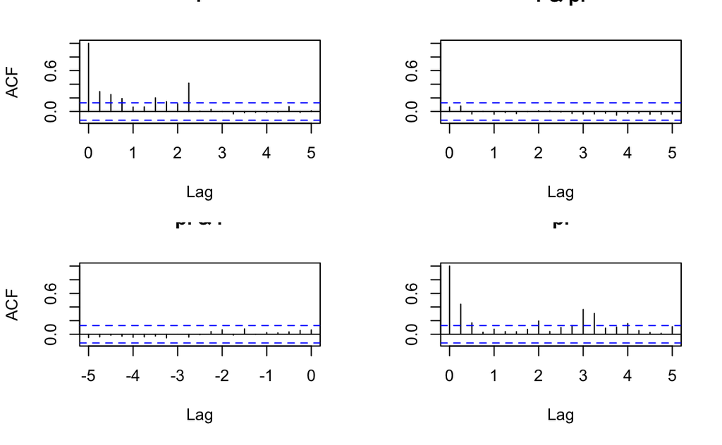

```r
TbGdpPi = read.csv("TbGdpPi.csv", header=TRUE)
TbPi.diff = ts(apply(TbGdpPi[,-2],2,diff), start=c(1955,2), freq=4)
plot(TbPi.diff)
acf(TbPi.diff^2)

source("SDAFE2.R")
mLjungBox(TbPi.diff^2, lag=8)
```

| K | Q(K) | d.f. | p-value |
| --- | --- | --- | --- |
| 8 | 132.57 | 32 | 0 |

Yes. First, the plots above shows clustering effects. Secondly, from the Ljung-Box test, there is strong evidence of correlation in the joint series. Finally, from the plot of TbPi.diff, we can see unstationarity. So it exhibit conditional heteroskedasticity.

```r
EWMA.param = est.ewma(lambda.0=0.95, innov=TbPi.diff)
EWMA.param$lambda.hat
```

```
[1] 0.8665812
```

```r
EWMA.Sigma=sigma.ewma(lambda=EWMA.param$lambda.hat,innov=TbPi.diff)
par(mfrow = c(2,2))
plot(ts(EWMA.Sigma[1,1,]^.5, start = c(1955, 2), frequency = 4),
     type = 'l', xlab = "year", ylab = NULL,
     main = expression(paste("(a) ", hat(sigma)["1,t"])))
plot(ts(EWMA.Sigma[1,2,], start = c(1955, 2), frequency = 4),
     type = 'l', xlab = "year", ylab = NULL,
     main = expression(paste("(b) ", hat(sigma)["12,t"])))
```

[figure not shown]

```r
plot(ts(EWMA.Sigma[1,2,]/(sqrt(EWMA.Sigma[1,1,]* EWMA.Sigma[2,2,])),
        start = c(1955, 2), frequency = 4),
     type = 'l', xlab = "year", ylab = NULL,
     main = expression(paste("(c) ", hat(rho)["12,t"])))
plot(ts(EWMA.Sigma[2,2,]^.5, start = c(1955, 2), frequency = 4),
     type = 'l', xlab = "year", ylab = NULL,
     main = expression(paste("(d) ", hat(sigma)["2,t"])))
```

From the estimates above, the estimated parameter is 0.8665812.

[output not shown]

Form the Ljung-Box test of the squared standardized residuals, the p-value is 0.002, which is significantly smaller than 0.05, showing strong evidence of serial correlation. So the EWMA model is not adequate.